# Comparative Analysis of Predictive Models for Heart Disease Classification

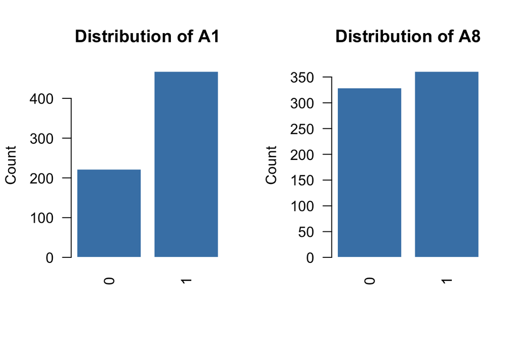

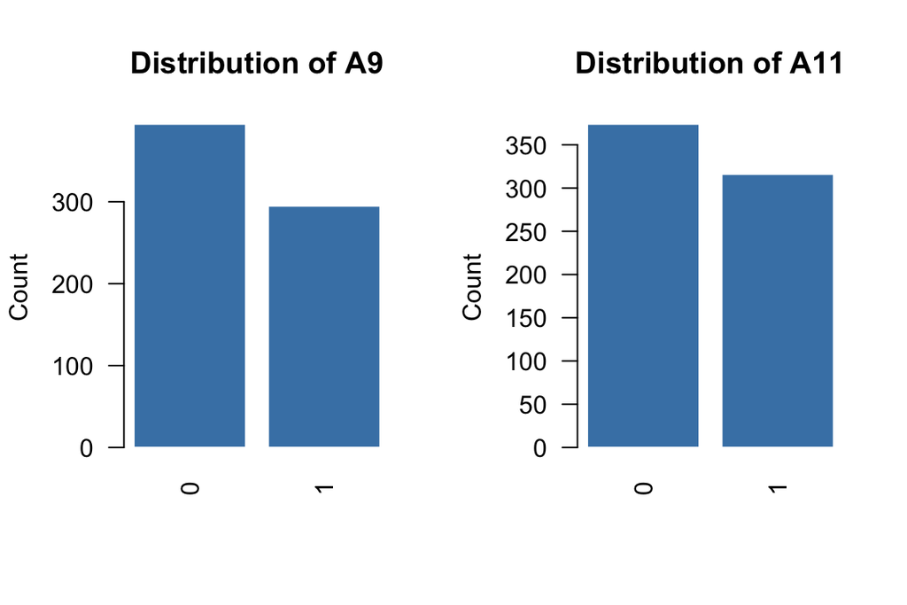

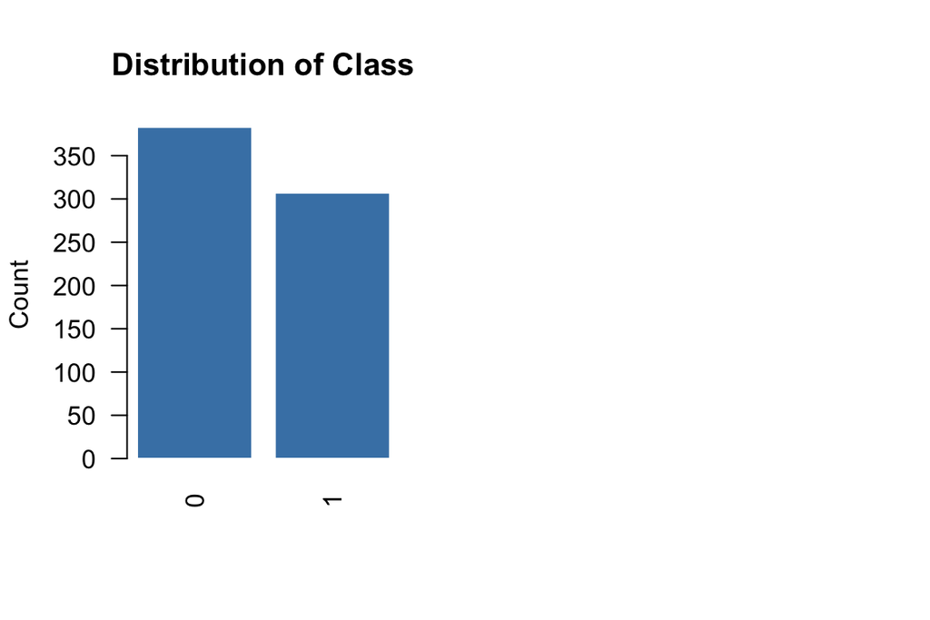

```r
for (v in cat_vars) {
  tbl <- table(mydata[[v]])
  barplot(tbl,
          main = paste("Distribution of", v),
          col = "steelblue",
          border = "white",
          ylab = "Count",
          las = 2)
}
```

# Model Building

To prepare the dataset for modeling, we first conducted exploratory data analysis (EDA) to understand the structure, distributions, and relationships among the variables, followed by basic feature engineering to clean and organize the data for downstream analysis. After establishing a reliable analytical dataset, we applied several unsupervised machine learning techniques to extract informative patterns and reduce dimensionality. Principal Component Analysis (PCA) was used to uncover the dominant sources of variation and generate compact feature representations. Clustering methods were then employed to identify natural groupings and behavioral segments within the data. Finally, the Local Outlier Factor (LOF) algorithm was used to detect anomalous observations that may influence modeling or represent meaningful deviations in customer behavior. Together, these methods provide a structured foundation for understanding the dataset and enhancing model performance in subsequent supervised learning tasks.

```r
num_data <- mydata[sapply(mydata, is.numeric)]

# Compute correlation matrix
cor_matrix <- cor(num_data, use = "pairwise.complete.obs")
print(cor_matrix)
```

```
             CustomerID            A1           A2          A3           A4
CustomerID  1.000000000 -0.0176690974  0.001531491  0.04840538  0.071517441
A1         -0.017669097  1.0000000000  0.036659321 -0.02816634 -0.063528161
A2          0.001531491  0.0366593207  1.000000000  0.20131524  0.089503247
A3          0.048405378 -0.0281663404  0.201315238  1.00000000  0.091526024
A4          0.071517441 -0.0635281608  0.089503247  0.09152602  1.000000000
A5         -0.053314320 -0.0053213443 -0.093876867  0.02766491  0.088846105
A6         -0.056551724  0.0526577428  0.028510074  0.09450422  0.046639021
A7          0.055084229  0.0970093990  0.392787871  0.29890156  0.080624256
A8          0.041008896  0.0009182252  0.204342263  0.24431672  0.129863180
A9          0.019781447 -0.0632557880  0.083679799  0.17484594  0.162464416
A10        -0.006900370 -0.0084273404  0.185573830  0.27120674  0.106457267
A11        -0.002839144  0.0539843221  0.054779100 -0.01302343  0.004963695
A12         0.015464248 -0.0599006635  0.020702508  0.09375167  0.006399956
A13        -0.020295269  0.0585954466 -0.077158942 -0.22234629 -0.001757719
A14         0.040060224  0.0036156380  0.018538695  0.12312115  0.120065000
Class       0.035399699 -0.0138970694  0.161625866  0.20629374  0.194306066
                     A5          A6          A7            A8          A9
CustomerID -0.053314320 -0.05655172  0.05508423  0.0410088964  0.01978145
A1         -0.005321344  0.05265774  0.09700940  0.0009182252 -0.06325579
A2         -0.093876867  0.02851007  0.39278787  0.2043422627  0.08367980
A3          0.027664914  0.09450422  0.29890156  0.2443167208  0.17484594
A4          0.088846105  0.04663902  0.08062426  0.1298631797  0.16246442
A5          1.000000000  0.40228376  0.14475699  0.3118325808  0.22295720
A6          0.402283761  1.00000000  0.24039951  0.2461930486  0.08039692
A7          0.144756992  0.24039951  1.00000000  0.3456887559  0.22298177
A8          0.311832581  0.24619305  0.34568876  1.0000000000  0.43203236
A9          0.222957198  0.08039692  0.22298177  0.4320323641  1.00000000
A10         0.150165862  0.09884073  0.32232967  0.3795319648  0.57149811
A11         0.024738143  0.09364113  0.13813938  0.0912757632  0.01704281
A12         0.070222095  0.03643483 -0.01629654  0.0450535439  0.17609731
A13         0.088139683  0.07066176 -0.07638852 -0.0673868187 -0.05332075
A14         0.030735269  0.06484085  0.05134493  0.0900119022  0.07765182
Class       0.373711613  0.24656749  0.32247536  0.7204068159  0.45830133
                    A10          A11          A12          A13         A14
CustomerID -0.006900370 -0.002839144  0.015464248 -0.020295269 0.040060224
A1         -0.008427340  0.053984322 -0.059900664  0.058595447 0.003615638
A2          0.185573830  0.054779100  0.020702508 -0.077158942 0.018538695
A3          0.271206739 -0.013023430  0.093751666 -0.222346295 0.123121153
A4          0.106457267  0.004963695  0.006399956 -0.001757719 0.120065000
```

[output cut: 13 more lines]

```
A1         -0.01389707
A2          0.16162587
A3          0.20629374
A4          0.19430607
A5          0.37371161
A6          0.24656749
A7          0.32247536
A8          0.72040682
A9          0.45830133
A10         0.40641001
A11         0.03162481
A12         0.11526093
A13        -0.09997241
A14         0.17565720
Class       1.00000000
```

```r
# Identify pairs with abs(correlation) > 0.7
high_corr <- which(abs(cor_matrix) > 0.7 & abs(cor_matrix) < 1, arr.ind = TRUE)

# Print readable results
if (nrow(high_corr) == 0) {
  cat("No numeric variables have correlation above 0.7\n")
} else {
  for (i in 1:nrow(high_corr)) {
    var1 <- rownames(cor_matrix)[high_corr[i, 1]]
    var2 <- colnames(cor_matrix)[high_corr[i, 2]]
    value <- cor_matrix[high_corr[i, 1], high_corr[i, 2]]
    cat(var1, "and", var2, "have correlation =", round(value, 3), "\n")
  }
}
```

```
CustomerID and CustomerID have correlation = 1
A8 and A8 have correlation = 1
Class and A8 have correlation = 0.72
A10 and A10 have correlation = 1
A8 and Class have correlation = 0.72
```

```r
# Convert to proper data frame
mydata <- as.data.frame(mydata)

# Keep only numeric columns
num_vars <- mydata[, sapply(mydata, is.numeric), drop = FALSE]

# Check for NA, Inf, -Inf
colSums(!is.finite(as.matrix(num_vars)))
```

```
CustomerID         A1         A2         A3         A4         A5         A6
         0          0          0          0          0          0          0
        A7         A8         A9        A10        A11        A12        A13
         0          0          0          0          0          0          0
       A14      Class
         0          0
```

```r
# Remove rows with NA or Inf
num_vars_clean <- num_vars[
  complete.cases(num_vars) &
    apply(num_vars, 1, function(x) all(is.finite(x))),
]

# Run PCA
pca_model <- prcomp(num_vars_clean, center = TRUE, scale = TRUE)

# PCA results
summary(pca_model)
```

```
Importance of components:
                          PC1     PC2     PC3     PC4     PC5     PC6    PC7
Standard deviation     1.8271 1.23189 1.16546 1.06900 1.02639 1.00429 0.9782
Proportion of Variance 0.2086 0.09485 0.08489 0.07142 0.06584 0.06304 0.0598
Cumulative Proportion  0.2086 0.30349 0.38838 0.45980 0.52564 0.58868 0.6485
                           PC8     PC9    PC10    PC11    PC12    PC13    PC14
Standard deviation     0.96146 0.90805 0.89549 0.87421 0.79526 0.73316 0.69960
Proportion of Variance 0.05778 0.05153 0.05012 0.04777 0.03953 0.03359 0.03059
Cumulative Proportion  0.70626 0.75779 0.80791 0.85568 0.89520 0.92880 0.95939
                          PC15    PC16
Standard deviation     0.62543 0.50856
Proportion of Variance 0.02445 0.01616
Cumulative Proportion  0.98384 1.00000
```

```r
round(pca_model$rotation, 2)
```

```
             PC1   PC2   PC3   PC4   PC5   PC6   PC7   PC8   PC9  PC10  PC11
CustomerID -0.03 -0.15 -0.03 -0.44  0.23 -0.39  0.62  0.37  0.14 -0.08  0.10
A1          0.00  0.11  0.39  0.04 -0.21  0.21  0.61 -0.49  0.06  0.33 -0.04
A2         -0.19 -0.32  0.44 -0.07 -0.05  0.04 -0.25 -0.04  0.43 -0.28 -0.24
A3         -0.25 -0.34  0.08 -0.03 -0.31 -0.18 -0.08  0.08 -0.31  0.12  0.44
A4         -0.15 -0.03 -0.12 -0.43  0.26 -0.30 -0.33 -0.42  0.25  0.51  0.03
A5         -0.24  0.49 -0.15  0.16 -0.09 -0.23  0.02  0.04  0.10  0.04  0.06
A6         -0.21  0.43  0.13  0.09 -0.35 -0.31 -0.08  0.12  0.11  0.04  0.20
A7         -0.32 -0.11  0.44  0.00 -0.08 -0.08 -0.02  0.08  0.13 -0.10  0.15
A8         -0.43  0.09  0.01  0.06  0.14 -0.04  0.09  0.01 -0.15 -0.14 -0.39
A9         -0.36 -0.04 -0.26  0.06  0.27  0.34  0.08 -0.02  0.04  0.05  0.22
A10        -0.37 -0.16 -0.09  0.14  0.18  0.31  0.06 -0.06 -0.02  0.01  0.39
A11        -0.05  0.21  0.38 -0.25  0.16  0.32 -0.16  0.51 -0.28  0.46 -0.14
A12        -0.10 -0.09 -0.37 -0.13 -0.49  0.33  0.06  0.31  0.51  0.21 -0.14
A13         0.08  0.46  0.12 -0.33  0.19  0.29 -0.06 -0.05  0.24 -0.40  0.34
A14        -0.11  0.03 -0.14 -0.60 -0.40  0.14 -0.03 -0.23 -0.41 -0.27 -0.07
Class      -0.44  0.10 -0.11  0.01  0.09 -0.05  0.09 -0.07 -0.11 -0.10 -0.40
            PC12  PC13  PC14  PC15  PC16
CustomerID  0.08  0.03 -0.13  0.02 -0.01
A1         -0.09  0.02 -0.07 -0.04  0.00
A2          0.03  0.03 -0.52 -0.08 -0.03
A3         -0.59  0.01 -0.12 -0.07 -0.08
A4         -0.03  0.03  0.09  0.06  0.06
A5         -0.04 -0.63 -0.40  0.02  0.09
A6          0.30  0.60 -0.01 -0.07 -0.03
A7          0.22 -0.41  0.64 -0.05  0.02
A8         -0.30  0.20  0.12  0.04  0.66
A9          0.14  0.05 -0.06 -0.72 -0.03
A10         0.27  0.08 -0.16  0.64  0.07
A11         0.04 -0.04 -0.13  0.02 -0.04
A12        -0.14  0.00  0.16  0.10  0.05
A13        -0.42  0.07  0.11  0.07 -0.05
A14         0.31 -0.10 -0.08 -0.04  0.09
Class      -0.15  0.06  0.11  0.14 -0.72
```

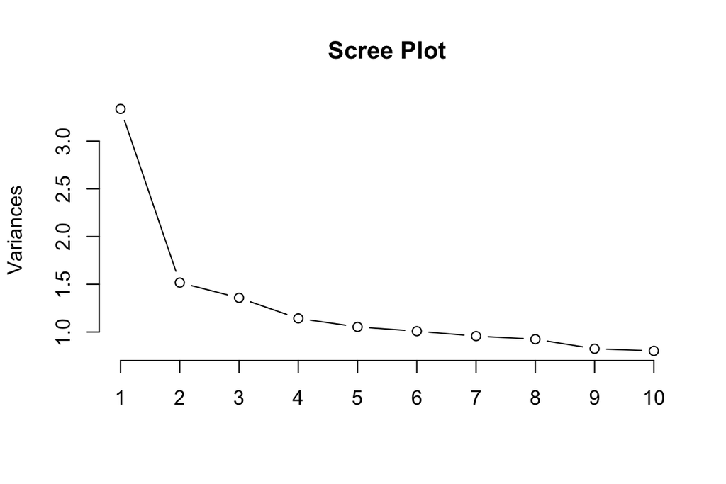

```r
# Scree plot
screeplot(pca_model, type = "lines", main = "Scree Plot")
```

```r
# Add first two PCs back to cleaned dataset
final_data <- mydata[rownames(num_vars_clean), ]
final_data$PC1 <- pca_model$x[,1]
final_data$PC2 <- pca_model$x[,2]
```

## Principle Component Analysis (PCA)

Given that the dataset contains multiple numerical variables with different scales, skewed distributions, and potential redundancy, Principal Component Analysis (PCA) was used to uncover the main patterns of variation and create a more compact representation of the data. PCA was applied to the nine continuous features (A2, A3, A5, A6, A7, A10, A12, A13, and A14) after centering and scaling them to ensure equal contribution across variables with vastly different ranges. The resulting components summarize the underlying structure of the dataset, allowing us to identify which combinations of variables explain most of the variability. Scree plots and component loadings were examined to determine how many components to retain, and the first two principal components were added back to the dataset for use in clustering and later modeling. This step provides a cleaner feature space, reduces noise from highly skewed variables, and helps reveal latent behavioral dimensions within the customer population.

```r
num_vars <- mydata[, c("A2","A3","A5","A6","A7","A10","A12","A13","A14")]

# Check for missing or infinite values
colSums(!is.finite(as.matrix(num_vars)))  # should all be 0
```

```
 A2  A3  A5  A6  A7 A10 A12 A13 A14
  0   0   0   0   0   0   0   0   0
```

```r
# Perform PCA (center and scale)
pca_result <- prcomp(num_vars, center = TRUE, scale. = TRUE)

# Summary: standard deviation, proportion of variance, cumulative proportion
summary(pca_result)
```

```
Importance of components:
                          PC1    PC2    PC3    PC4     PC5    PC6     PC7
Standard deviation     1.4286 1.2001 1.0720 1.0078 0.91725 0.8828 0.81364
Proportion of Variance 0.2268 0.1600 0.1277 0.1129 0.09348 0.0866 0.07356
Cumulative Proportion  0.2268 0.3868 0.5145 0.6273 0.72083 0.8074 0.88098
                           PC8     PC9
Standard deviation     0.74449 0.71895
Proportion of Variance 0.06159 0.05743
Cumulative Proportion  0.94257 1.00000
```

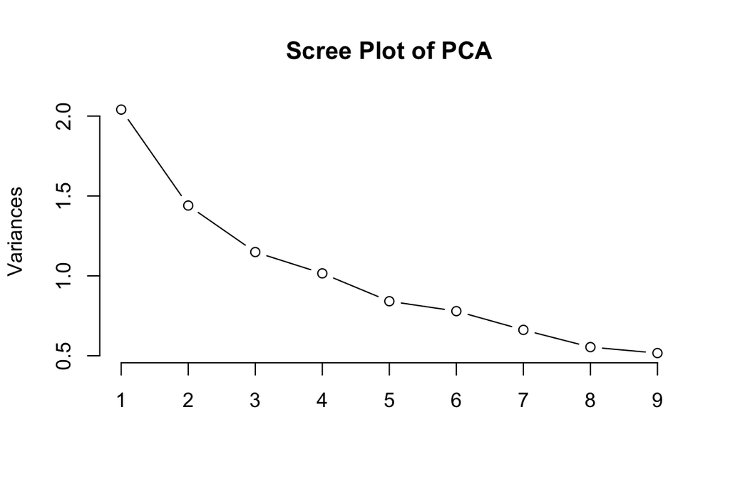

```r
# Scree plot to visualize variance explained
screeplot(pca_result, type = "lines", main = "Scree Plot of PCA")
```

```r
# Factor loadings (which variables contribute most to each PC)
round(pca_result$rotation, 2)
```

```
      PC1   PC2   PC3   PC4   PC5   PC6   PC7   PC8   PC9
A2   0.36 -0.32  0.28 -0.36  0.40 -0.27  0.15 -0.20 -0.52
A3   0.43 -0.22 -0.16  0.08 -0.40 -0.08 -0.73 -0.12 -0.13
A5   0.23  0.61  0.01  0.27  0.01  0.07  0.11 -0.68 -0.12
A6   0.30  0.54  0.11  0.10 -0.06 -0.41  0.01  0.62 -0.20
A7   0.52 -0.04  0.30 -0.15  0.06 -0.07  0.08 -0.05  0.77
A10  0.44 -0.06 -0.05  0.11  0.05  0.79  0.18  0.29 -0.19
A12  0.14  0.03 -0.69  0.09  0.66 -0.12 -0.14  0.05  0.15
A13 -0.17  0.41  0.17 -0.61  0.23  0.31 -0.50  0.03  0.01
A14  0.14  0.11 -0.53 -0.60 -0.43 -0.05  0.36 -0.05 -0.02
```

```r
# Extract the PC scores (transformed values of original data)
pc_scores <- pca_result$x
head(pc_scores[, 1:2])  # first two PCs
```

```
            PC1        PC2
[1,] -0.2192484 -0.9444448
[2,] -0.6521871  0.0346025
[3,] -1.0992315 -0.3097754
[4,]  0.5033837 -1.4110168
[5,]  0.9033316 -0.6957380
[6,] -0.3657530  1.4098516
```

```r
# Optionally, add first two PCs to the original dataset
mydata$PC1 <- pc_scores[,1]
mydata$PC2 <- pc_scores[,2]

# Save the new dataset with PCs
write.csv(mydata, "New_Data_with_PCs.csv", row.names = FALSE)
```

## Clustering

Clustering was used as an unsupervised learning approach to explore natural groupings within the dataset based solely on similarity among the numeric features. After preparing the data through scaling and dimensionality reduction with PCA, clustering algorithms were applied to identify patterns or segments that may not be visible through traditional analysis. This process helps reveal underlying structure in the customer population and provides additional feature representations that can be incorporated into subsequent modeling.

### K-Means Clustering

K-means clustering is an unsupervised learning technique that partitions observations into a chosen number of clusters based on similarity. The algorithm works by iteratively assigning data points to the closest cluster center and then updating those centers to minimize the within-cluster variation. In this project, k-means was applied to the standardized scores of the first three principal components (PC1–PC3) to ensure that differences in scale did not bias the distance calculations. The elbow method and silhouette analysis were used to guide the selection of an appropriate number of clusters, after which the final model was fitted. Cluster memberships were then visualized in PCA space to examine how the groups formed within the reduced-dimensional representation of the data.

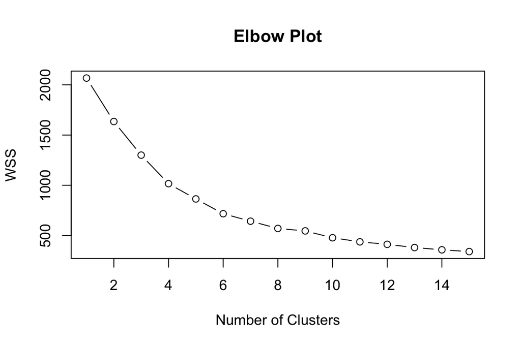

```r
clust.data <- pc_scores[, c("PC1", "PC2", "PC3")]
scaled.data <- scale(clust.data)


wss <- NULL
K <- 15
for (i in 1:K){
  wss[i] <- kmeans(scaled.data, centers = i, nstart = 25)$tot.withinss
}

plot(1:K, wss, type="b",
     xlab="Number of Clusters",
     ylab="WSS",
     main="Elbow Plot")
```

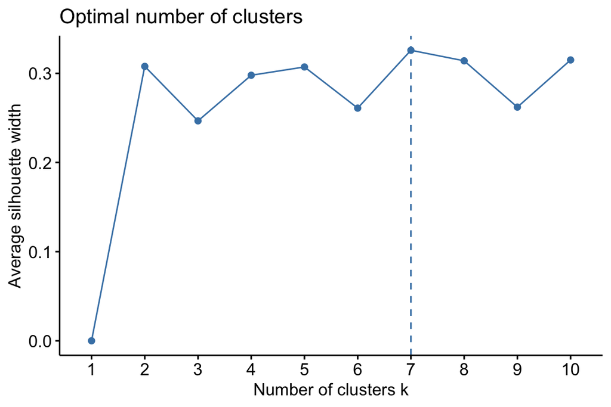

```r
library(factoextra)
fviz_nbclust(scaled.data, kmeans, method="silhouette")
```

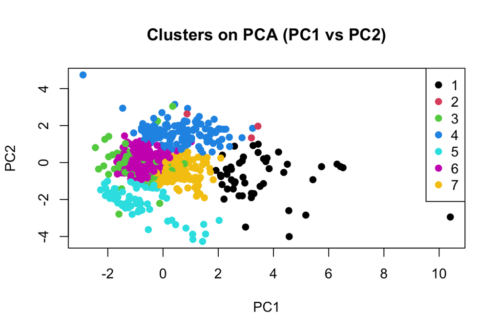

```r
# Use first 3 PCs
clust.data <- as.data.frame(pca_result$x[, 1:3])

# Scale before K-means
scaled.data <- scale(clust.data)

# Choose k = 7 based on silhouette
set.seed(123)
k_result <- kmeans(scaled.data, centers = 7, nstart = 50, iter.max = 100)

clust.data$cluster <- as.factor(k_result$cluster)

# Plot clusters
plot(clust.data$PC1, clust.data$PC2,
     col = clust.data$cluster,
     pch = 19,
     xlab = "PC1", ylab = "PC2",
     main = "Clusters on PCA (PC1 vs PC2)")

legend("topright",
       legend = levels(clust.data$cluster),
       col = 1:length(levels(clust.data$cluster)),
       pch = 19)
```

### Hierarchical Clustering

Hierarchical clustering is an unsupervised learning method that builds a tree-like structure (dendrogram) to represent how observations group together based on similarity. Unlike k-means, it does not require specifying the number of clusters upfront; instead, it iteratively merges the closest clusters using a chosen distance metric and linkage method. In this analysis, Euclidean distance and complete linkage were applied to the standardized principal component scores to create a hierarchical cluster tree. The dendrogram, along with the elbow and silhouette criteria, guided the selection of an appropriate cut level, and the resulting cluster assignments were visualized in the PCA space to illustrate how the hierarchical structure maps onto the reduced-dimensional representation of the data.

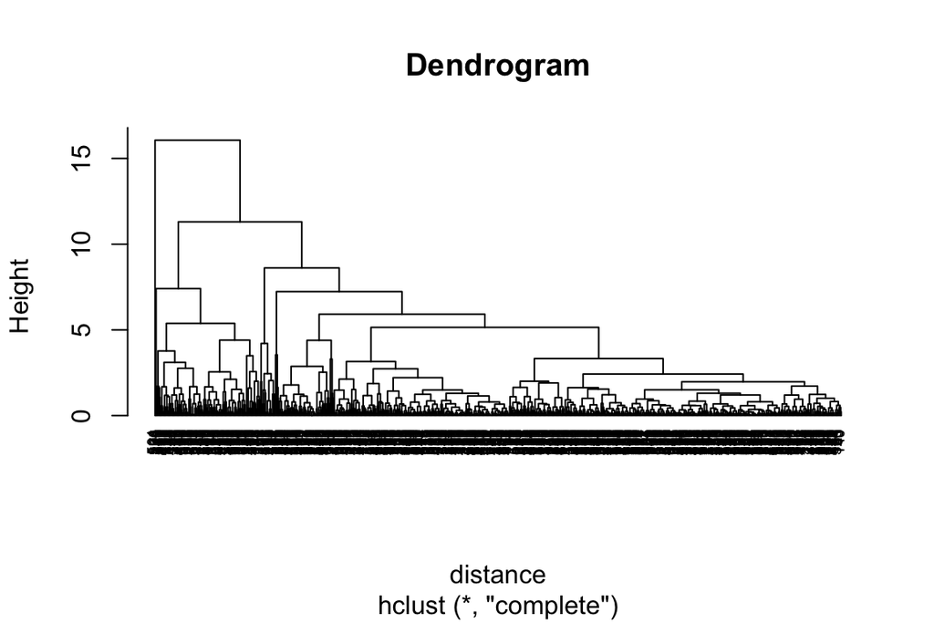

```r
distance <- dist(scaled.data, method="euclidean")

hc <- hclust(distance, method="complete")
plot(hc, cex=.6, hang=-1, main="Dendrogram")
```

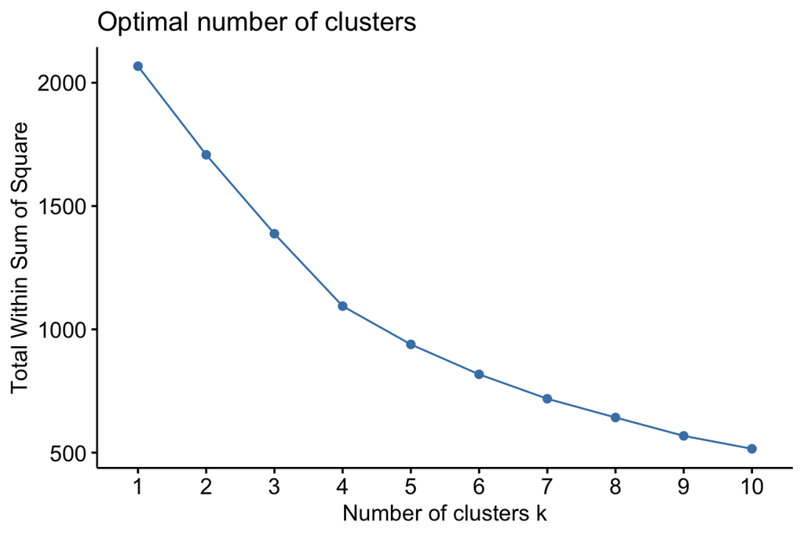

```r
fviz_nbclust(scaled.data, FUN = hcut, method = "wss")
```

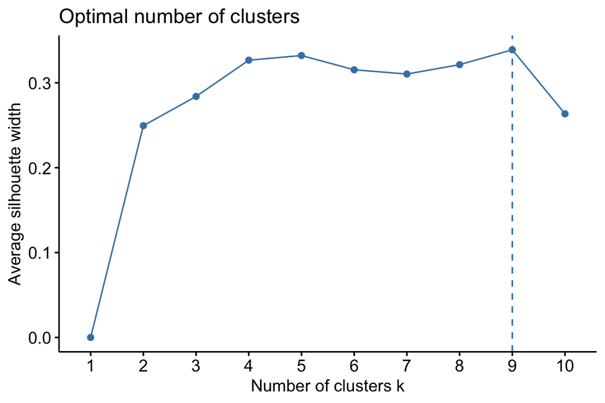

```r
fviz_nbclust(scaled.data, FUN = hcut, method = "silhouette")
```

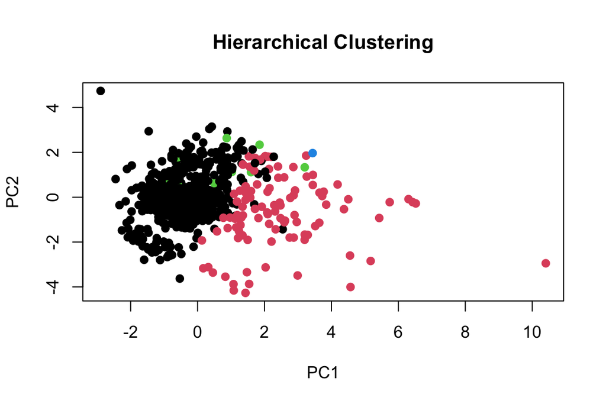

```r
group <- cutree(hc, k=4)
clust.data$HCgroup <- group

plot(clust.data$PC1, clust.data$PC2,
     pch = 19,
     col = factor(clust.data$HCgroup),
     xlab ="PC1",
     ylab = "PC2",
     main = "Hierarchical Clustering")
```

### Hierarchical Clustering Conclusion

When these four groups are plotted on the PCA space, the clusters appear partially overlapping, which means the differences between groups are subtle rather than sharply defined. One cluster is more spread along the positive PC1 direction, while the others are concentrated near the center of the PCA plot. This suggests that the strongest separation is driven by only one or two underlying dimensions, with most observations sharing similar feature patterns.

Overall, hierarchical clustering indicates that the dataset contains a few loosely defined subgroups, with moderate separation along the principal components. The structure is not strongly partitioned, but there are identifiable regions in the data where observations tend to cluster together based on their similarity in the selected numerical attributes.

## Local Outlier Factor (LOF)

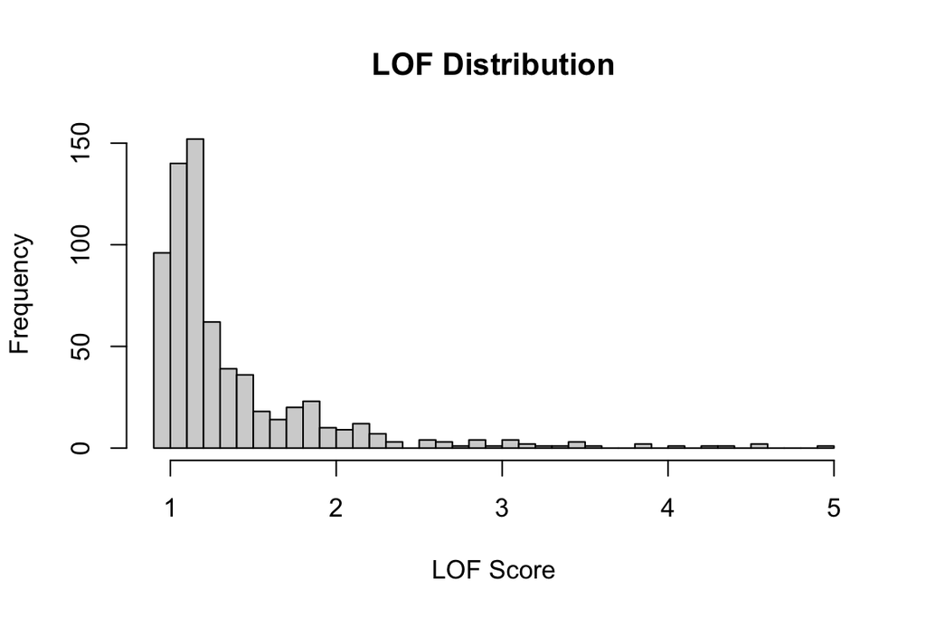

```r
library(dbscan)      # for LOF
library(pROC)      # for ROC curves

lof.Churn.100 <- lof(
  mydata[, c("A2","A3","A4","A5","A6","A7","A10","A11","A12","A13","A14")],
  k = 100
)

#summary(lof.Churn.100)


### 1. Your outcome variable (replace Class if needed)
num_cols <- c("A2","A3","A4","A5","A6","A7","A10","A11","A12","A13","A14")
mydata_numeric <- mydata[, num_cols]

# Remove rows with any NA in these variables
complete_rows <- complete.cases(mydata_numeric, mydata$Class)

mydata_numeric <- mydata_numeric[complete_rows, ]
category <- mydata$Churn[complete_rows]

### 3. Compute Local Outlier Factor
lof_scores <- dbscan::lof(mydata_numeric, k = 100)

### 4. Plot LOF distribution (excluding giant outliers)
hist(lof_scores[lof_scores < 5],
     breaks = 50,
     main = "LOF Distribution",
     xlab = "LOF Score")
```

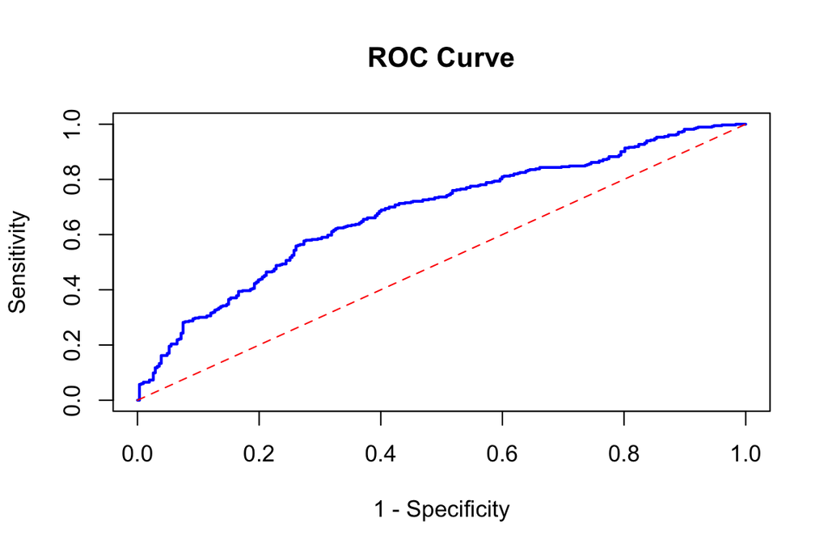

```r
### 5. Catching rate across thresholds
cut.lof <- seq(1, 5, length = 21)
catching_rate <- numeric(length(cut.lof))

for(i in 1:length(cut.lof)){
  ID <- lof_scores > cut.lof[i]
  fraud_sub <- mydata$Class[ID]
  catching_rate[i] <- sum(fraud_sub) / sum(ID)
}

default_rate <- sum(mydata$Class) / nrow(mydata)
relative_detect_rate <- (catching_rate - default_rate) / default_rate

### 6. ROC Curve
category <- as.character(mydata$Class)

#install.packages("Rlof")

# Compute LOF scores (k = 100)
lof_scores <- Rlof::lof(mydata_numeric, k = 100)

#length(category)
#length(lof_scores)

library(pROC)

category <- factor(category, levels = c(1, 0))

ROCobj <- roc(category, lof_scores, direction = ">")

plot(1 - ROCobj$specificities,
     ROCobj$sensitivities,
     type = "l", lwd = 2, col = "blue",
     xlab = "1 - Specificity", ylab = "Sensitivity",
     main = "ROC Curve")

segments(0,0,1,1,col="red",lty=2)
```

```r
#####     NOT NEEDED      #####




### 0. Identify correct churn column
# Replace "Churn" below if your column name is different (check with names(mydata))

### 1. Select numeric LOF columns
num_cols <- c("A2","A3","A4","A5","A6","A7","A10","A11","A12","A13","A14")

### 2. Build a clean dataset containing ONLY numeric columns + churn
df <- data.frame(mydata[, num_cols], Churn = mydata$Class)

### 3. Keep only complete rows
df <- df[complete.cases(df), ]

### 4. Extract cleaned columns
mydata_numeric <- df[, num_cols]
category <- df$Churn

### 5. Check lengths BEFORE LOF
print(length(category))
```

```
[1] 690
```

```r
print(nrow(mydata_numeric))
```

```
[1] 690
```

```r
### 6. Compute LOF with dbscan
library(dbscan)
lof_scores <- dbscan::lof(mydata_numeric, k = 100)

### 7. Check lengths match
print(length(category))
```

```
[1] 690
```

```r
print(length(lof_scores))
```

```
[1] 690
```

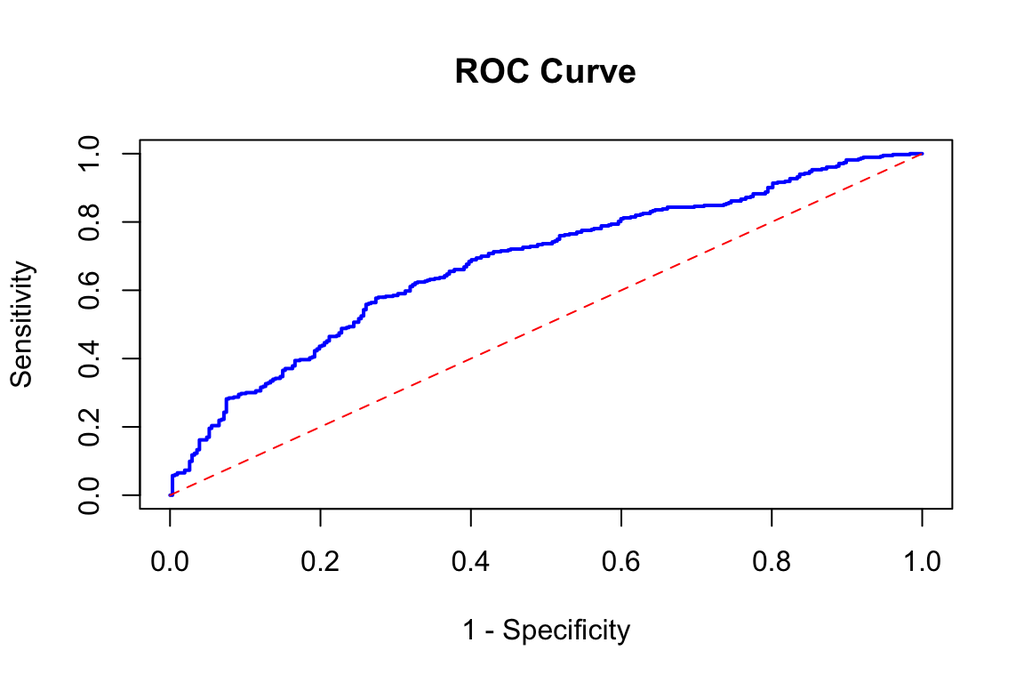

```r
### 8. ROC
library(pROC)
category <- factor(category, levels = c(1, 0))

ROCobj <- roc(category, lof_scores, direction = ">")

plot(1 - ROCobj$specificities,
     ROCobj$sensitivities,
     type = "l",
     lwd = 2, col = "blue",
     xlab = "1 - Specificity",
     ylab = "Sensitivity",
     main = "ROC Curve")

segments(0,0,1,1, col="red", lty=2)
```

## Local Outlier Factor Conclusion

When LOF is used as a predictor for the Class label, the ROC curve shows performance moderately above random chance but not strong enough for reliable classification. The curve rises above the diagonal baseline, suggesting that higher LOF scores are associated with a higher probability of being in the positive (Class 1) category, but the separation is weak. This means LOF captures some signal about abnormal behavior related to the outcome, but most observations labeled as positive are not extreme outliers, and many high-LOF cases belong to the negative class.

Overall, LOF reveals that the dataset contains few true structural outliers, and while outlierness correlates slightly with the outcome, LOF alone is not an effective classifier. It is better used as an additional feature to highlight unusual patterns rather than as a standalone prediction method.